# Project 1

Shane Hylton

9/18/2021

## Reading the Chess Data

```r
link <- "https://raw.githubusercontent.com/st3vejobs/DATA-607-Project-1/main/tournamentinfo.txt"
library(stringr)
data <- readLines(link)
data <- data[-c(1,2,3,4)]
#data <- read.table(file = url(link), header = TRUE)
namerows <- unlist(data)
namerows <- namerows[seq(1,length(namerows),by = 3)]
rtgrows <- unlist(data)
rtgrows <- rtgrows[seq(2, length(rtgrows), by = 3)]
```

## Final Data Frame

My next move is to take the individual data and compile it into a new data frame. I do this column by column, using only one for loop. I find it awfully challenging to communicate the proper regexps. It requires a lot of trial and error for me. R for Data Science is a helpful text, but it still takes me a long time to figure out each line for a regexp. This project is a great way to combine a large number of the regex commands into one assignment.

As practice, I added two plots, one for strength of schedule colored by state, and another for player rating vs. opponent average rating.

```r
names <- str_extract(namerows, '[A-Z].{1,30}')
names <- c(str_trim(str_extract(names, '.+\\s{2,}')))
Final <- data.frame(names)
colnames(Final) <- c("Name")

initials <- str_extract_all(names, '(^[A-Z])|(\\s)([A-Z])')
first_initial <- str_extract(names, '^[A-Z]')
Final$Initial <- c(first_initial)
states <- str_extract(rtgrows, '[A-Z]{2}')
Final$State <- states

pts <- c(as.numeric(str_extract(namerows, '\\d+\\.\\d')))
Final$Points <- pts

rtgraw <- str_extract(rtgrows, 'R:.{7,}-')
rtg <- c(as.numeric(str_extract(rtgraw, '\\d{1,5}')))
Final$Pre_Match_Rating <- rtg
opp_idx <- str_extract_all(namerows, '[A-Z]\\s{2,}\\d+')
opp_idx <- c(str_extract_all(opp_idx, '\\d+'))
avgrtg <- c()
for(i in c(1:length(opp_idx))){
  avgrtg[i] <- round(mean(rtg[as.numeric(opp_idx[[i]])]),0)
}

Final$Average_Opponent_Rating <- avgrtg

write_csv(Final, '/Users/shanehylton/Desktop/quickview_chess.csv')
```

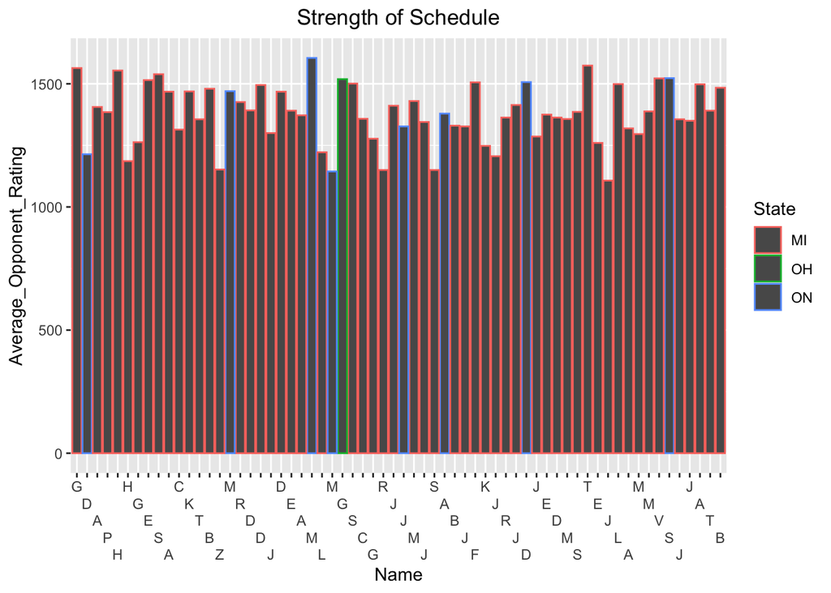

```r
library(ggplot2)

ggplot(Final, aes(x = Name, y = Average_Opponent_Rating, color = State))+
  geom_bar(stat = "identity", position= position_dodge())+
  ggtitle('Strength of Schedule')+
  scale_x_discrete(labels = c(Final$Initial), guide = guide_axis(n.dodge=5))+
  theme(plot.title = element_text(hjust = 0.5))
```

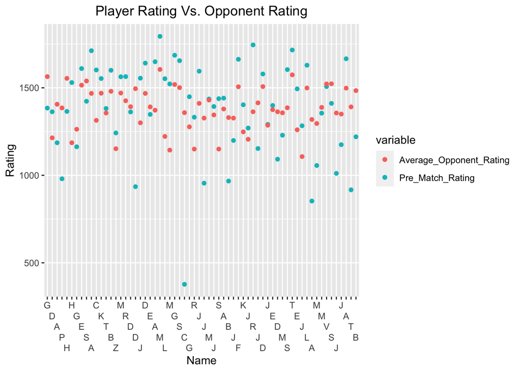

```r
ggplot(Final, aes(x = Name, y = value, color = variable))+
  geom_point(aes(y = Pre_Match_Rating, col = "Pre_Match_Rating"))+
  geom_point(aes(y = Average_Opponent_Rating, col = "Average_Opponent_Rating"))+
  ggtitle('Player Rating Vs. Opponent Rating')+
  ylab("Rating")+
  scale_x_discrete(labels = c(Final$Initial), guide = guide_axis(n.dodge=5))+
  theme(plot.title = element_text(hjust = 0.5))
```

## Using Elo to calculate expected Scores

I used the provided Elo calculation to compute the expected wins for each participant. I displayed the name of the player who most exceeded expectations. Below I provided a simple plot of actual points vs. expected points.

```r
difference <- c(Final$Average_Opponent_Rating - Final$Pre_Match_Rating)
ratio <- difference/400
exponent <- 10^ratio
expected <- round((1/(1 + exponent))*7,2) #Multiplied by expected games played
Final$Expected_Points <- expected
actual_minus <- c(as.numeric(Final$Points)) - c(as.numeric(Final$Expected_Points))
Final$Actual_Minus_Expected <- actual_minus
upset = as.numeric(which(Final$Actual_Minus_Expected == max(Final$Actual_Minus_Expected)))

Final$Name[upset] #Name of the participant who performed most above expectations
```

```
## [1] "ADITYA BAJAJ"
```

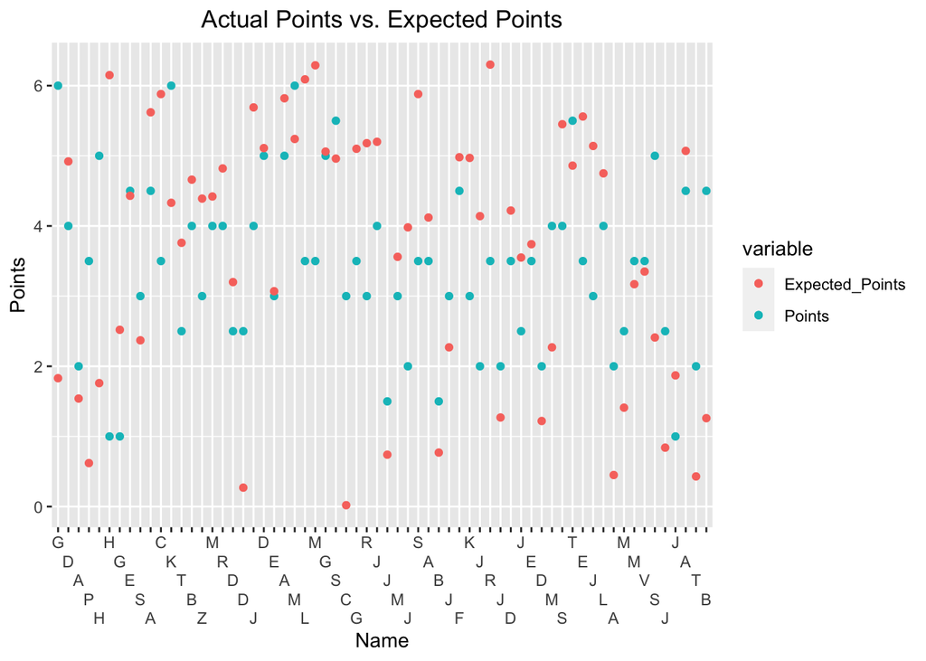

```r
ggplot(Final, aes(x = Name, y = value, color = variable))+
  geom_point(aes(y = Points, col = "Points"))+
  geom_point(aes(y = Expected_Points, col = "Expected_Points"))+
  ggtitle('Actual Points vs. Expected Points')+
  ylab("Points")+
  scale_x_discrete(labels = c(Final$Initial), guide = guide_axis(n.dodge=5))+
  theme(plot.title = element_text(hjust = 0.5))
```